# Visualizing Network Data

Quang Duong

2017-07-27

The cliche goes that the world is an increasingly interconnected place, and the connections between different entities are often best represented with a graph. Graphs are comprised of vertices (also often called “nodes”) and edges connecting those nodes. In this assignment, we will learn how to visualize networks using the igraph package in R.

For this assignment, we will visualize social networking data using anonymized data from Facebook; this data was originally curated in a recent paper about computing social circles in social networks. In our visualizations, the vertices in our network will represent Facebook users and the edges will represent these users being Facebook friends with each other.

The first file we will use, edges.csv, contains variables V1 and V2, which label the endpoints of edges in our network. Each row represents a pair of users in our graph who are Facebook friends. For a pair of friends A and B, edges.csv will only contain a single row – the smaller identifier will be listed first in this row. From this row, we will know that A is friends with B and B is friends with A.

The second file, users.csv, contains information about the Facebook users, who are the vertices in our network. This file contains the following variables:

*id*: A unique identifier for this user; this is the value that appears in the rows of edges.csv

*gender*: An identifier for the gender of a user taking the values A and B. Because the data is anonymized, we don’t know which value refers to males and which value refers to females.

*school*: An identifier for the school the user attended taking the values A and AB (users with AB attended school A as well as another school B). Because the data is anonymized, we don’t know the schools represented by A and B.

*locale*: An identifier for the locale of the user taking the values A and B. Because the data is anonymized, we don’t know which value refers to what locale.

## Summarizing the Data

Load the data from edges.csv into a data frame called edges, and load the data from users.csv into a data frame called users.

How many Facebook users are there in our dataset?

```r
edges <- read.csv("edges.csv")
users <- read.csv("users.csv")
str(edges)
str(users)
head(edges)
head(users)
```

```
'data.frame':   146 obs. of  2 variables:
 $ V1: int  4019 4023 4023 4027 3988 3982 3994 3998 3993 3982 ...
 $ V2: int  4026 4031 4030 4032 4021 3986 3998 3999 3995 4021 ...
'data.frame':   59 obs. of  4 variables:
 $ id    : int  3981 3982 3983 3984 3985 3986 3987 3988 3989 3990 ...
 $ gender: Factor w/ 3 levels "","A","B": 2 3 3 3 3 3 2 3 3 2 ...
 $ school: Factor w/ 3 levels "","A","AB": 2 1 1 1 1 2 1 1 2 1 ...
 $ locale: Factor w/ 3 levels "","A","B": 3 3 3 3 3 3 2 3 3 2 ...
    V1   V2
1 4019 4026
2 4023 4031
3 4023 4030
4 4027 4032
5 3988 4021
6 3982 3986
    id gender school locale
1 3981      A      A      B
2 3982      B             B
3 3983      B             B
4 3984      B             B
5 3985      B             B
6 3986      B      A      B
```

In our dataset, what is the average number of friends per user?

```r
146*2/59
```

```
[1] 4.949153
```

From str(edges) or nrow(edges), we see that there are 146 pairs of users in our dataset who are Facebook friends. However, each pair (A, B) must be counted twice, because B is a friend of A and A is a friend of B.

Out of all the students who listed a school, what was the most common locale?

```r
table(users[users$school != "","locale"])
```

```
    A  B
 0  0 19
```

Is it possible that either school A or B is an all-girls or all-boys school?

```r
table(users$gender, users$school)
```

```
        A AB
     1  1  0
  A 11  3  1
  B 28 13  1
```

No since we see that both genders A and B have attended schools A and B.

## Creating a Network

We will be using the igraph package to visualize networks; install and load this package using the install.packages and library commands.

```r
library(igraph)
```

We can create a new graph object using the graph.data.frame() function. Based on ?graph.data.frame, which of the following commands will create a graph g describing our social network, with the attributes of each user correctly loaded?

```r
g <- graph.data.frame(edges, directed = FALSE, vertices = users)
```

From ?graph.data.frame, we can see that the function expects the first two columns of parameter d to specify the edges in the graph – our edges object fits this description. Our edges are undirected – if A is a Facebook friend of B then B is a Facebook friend of A. Therefore, we set the directed parameter to FALSE. The vertices parameter expects a data frame where the first column is a vertex id and the remaining columns are properties of vertices in our graph. This is the case with our users data frame.

Now, we want to plot our graph. By default, the vertices are large and have text labels of a user’s identifier. Because this would clutter the output, we will plot with no text labels and smaller vertices:

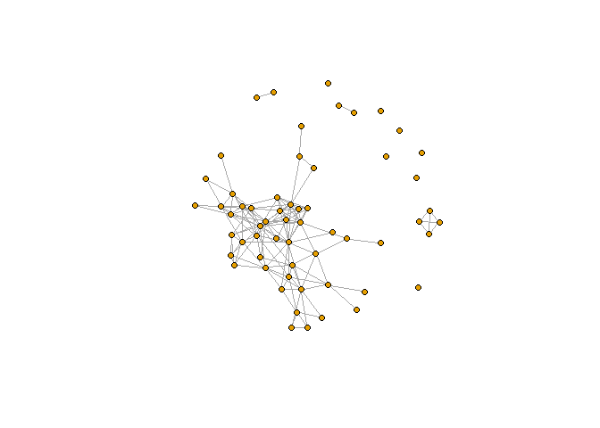

```r
plot(g, vertex.size=5, vertex.label=NA)
```

In this graph, there are a number of groups of nodes where all the nodes in each group are connected but the groups are disjoint from one another, forming “islands” in the graph. Such groups are called “connected components,” or “components” for short. How many connected components with at least 2 nodes are there in the graph?

In addition to the large connected component, there is a 4-node component and two 2-node components. There are 7 nodes that are not connected to any other nodes. Each forms a 1-node connected component.

In our graph, the “degree” of a node is its number of friends. We have already seen that some nodes in our graph have degree 0 (these are the nodes with no friends), while others have much higher degree. We can use degree(g) to compute the degree of all the nodes in our graph g.

How many users are friends with 10 or more other Facebook users in this network?

```r
sum(degree(g) >= 10)
table(degree(g))
table(degree(g)>=10)
```

```
[1] 9

 0  1  2  3  4  5  6  7  8  9 10 11 13 17 18
 7 10  4  9  1  4  4  3  6  2  4  1  2  1  1

FALSE  TRUE
   50     9
```

In a network, it’s often visually useful to draw attention to “important” nodes in the network. While this might mean different things in different contexts, in a social network we might consider a user with a large number of friends to be an important user. From the previous problem, we know this is the same as saying that nodes with a high degree are important users.

To visually draw attention to these nodes, we will change the size of the vertices so the vertices with high degrees are larger. To do this, we will change the “size” attribute of the vertices of our graph to be an increasing function of their degrees:

```r
V(g)$size = degree(g)/2 + 2
```

Now that we have specified the vertex size of each vertex, we will no longer use the vertex.size parameter when we plot our graph:

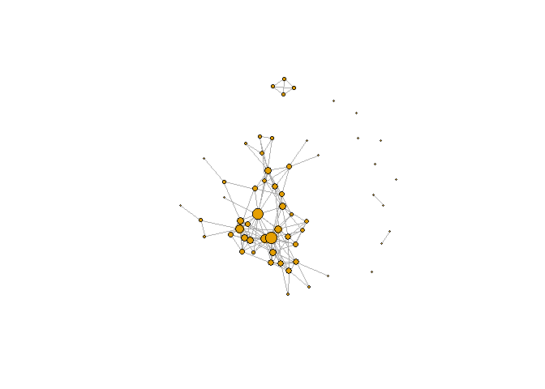

```r
plot(g, vertex.label=NA)
```

What is the largest size we assigned to any node in our graph?

```r
18/2+2
```

```
[1] 11
```

What is the smallest size we assigned to any node in our graph?

```r
0/2+2
```

```
[1] 2
```

Thus far, we have changed the “size” attributes of our vertices. However, we can also change the colors of vertices to capture additional information about the Facebook users we are depicting.

We can update the colors by setting the color to black for all vertices, than setting it to red for the vertices with gender A and setting it to gray for the vertices with gender B:

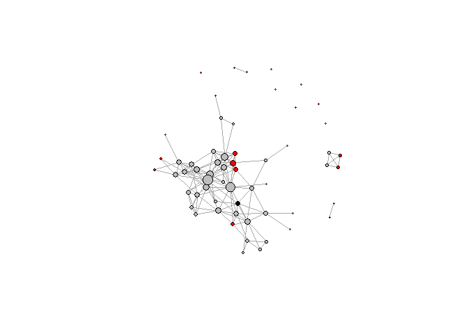

```r
V(g)$color <- "black"
V(g)$color[V(g)$gender=="A"] <- "red"
V(g)$color[V(g)$gender=="B"] <- "gray"
plot(g, vertex.label=NA)
```

All the largest nodes (the ones with the highest degree) are colored gray, which corresponds to Gender B.

Now, color the vertices based on the school that each user in our network attended.

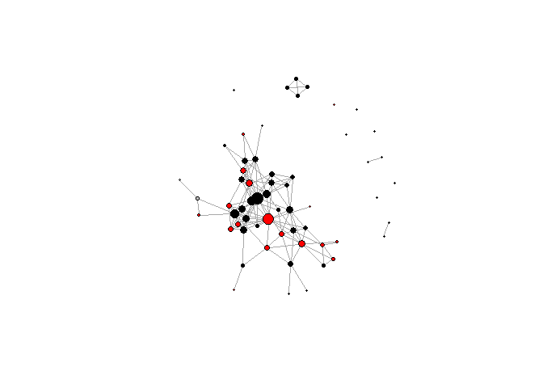

```r
V(g)$color <- "black"
V(g)$color[V(g)$school=="A"] = "red"
V(g)$color[V(g)$school=="AB"] = "gray"
plot(g, vertex.label=NA)
```

Are the two users who attended both schools A and B Facebook friends with each other?

What best describes the users with highest degree?

Now, color the vertices based on the locale of the user.

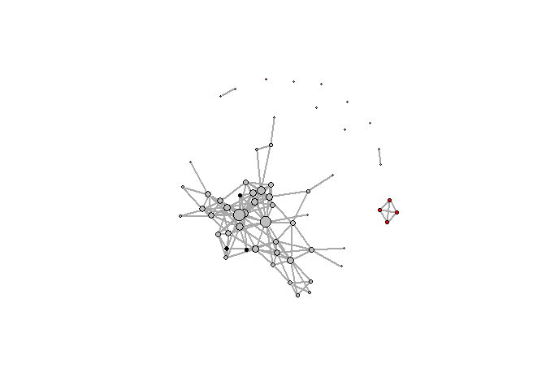

```r
V(g)$color="black"
V(g)$color[V(g)$locale=="A"] = "red"
V(g)$color[V(g)$locale=="B"] = "gray"
plot(g, vertex.label=NA, edge.width=2)
```

Nearly all of the vertices from the large connected component are colored gray, indicating users from Locale B. Meanwhile, all the vertices in the 4-user connected component are colored red, indicating users from Locale A.

## Other Plotting Options

The help page is a helpful tool when making visualizations. Answer the following questions with the help of ?igraph.plotting and experimentation in your R console.